# 0 - Install packages

Gráfico 2 - Densidade de inquiridos por idade

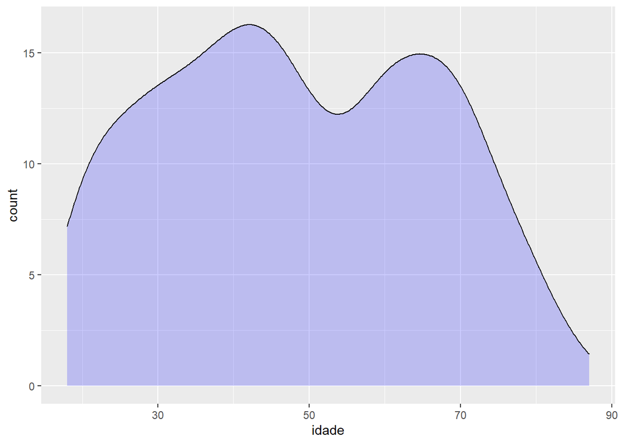

```r
##Gráfico 2
ggplot(data = data, aes(x = idade, y = ..count..)) + geom_density(alpha = .2, fill = "blue")
```

Ao analisar este gráfico, verificamos que, de um modo geral este questionário atingiu um público com idades muito variadas desde os 18 aos 87 anos. De qualquer das maneiras, a partir dos 70 anos podemos observar uma queda dos inquiridos. Gráfico 3 - Distribuicao do agregado dos inquiridos

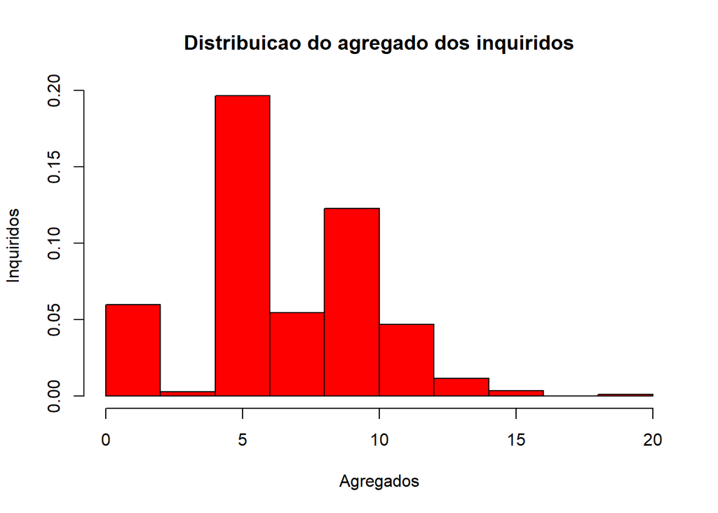

```r
##Gráfico 3
hist(data$agregado, main = "Distribuicao do agregado dos inquiridos", xlab = "Agregados", ylab = "Inquiridos", col = "red", prob=TRUE)
```

O gráfico 3, revela a distribuição dos agregados dos vários inquiridos. Com a observação deste histograma, verificamos que na grande na maioria dos inquiridos, os seus respetivos agregados são compostos entre 5 a 10 elementos sendo aquele que possui o valor máximo o 5 que corresponde a aproximadamente 300 dos inquiridos. Gráfico 4 - Variacão do agregado familiar baseado na resposta à pPreocuparDemasiado

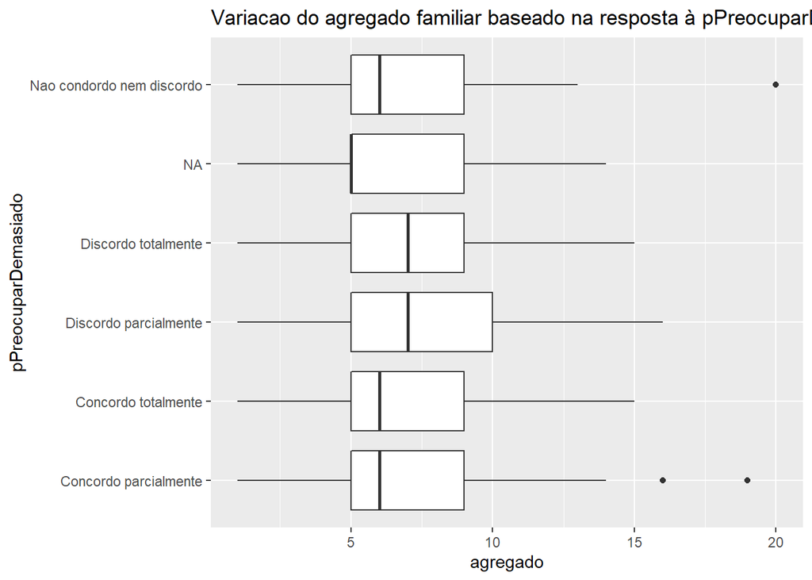

```r
##Gráfico 4
ggplot2::qplot(data = data, x = agregado, y= pPreocuparDemasiado, geom="boxplot", main = "Variacao do agregado familiar baseado na resposta à pPreocuparDemasiado")
```

O diagrama de extremos e quartis representado no gráfico 4 revela que, dos imquiridos que responderam à pergunta “as pessoas preocupam-se demasiado com os efeitos negativos do progresso sobre. o ambiente”, cerca de 50% tem um agregado de 5 a 10 pessoas. Observando este diagrama podemos retirar que a mediana costuma tomar os valores de 6 e 7 dividindo os nossos dados em dois segmentos de igual comprimento. Em adição, o primeiro quartil toma sempre o valor de 5 e o terceiro quartil assume como valores 9 e 10. Para além disso, a distribuição da amostra é assimétrica positiva, visto que os dados se concentram mais à esquerda do eixo do x.